# ДЗ 1 задача 3

## Юдина Екатерина БПИ198

### Вариант 1, проверяющая Дубина Н.А., nadubina@edu.hse.ru.

$\underline{Условие :}$

Производитель газированной воды, планирующий продвижение нового товара (вода A), заказал вам малое обследование потенциальных потребителей. Вы уже собрали нужные данные и записали их в файл «Данные к задаче 3.ods»:

a — общая оценка респондентом воды A по семибалльной шкале (1 — совсем не понравилось, 7 — превосходно);

b — оценка респондентом воды B (предполагаемого конкурента);

sex — пол респондента (0 — мужской, 1 — женский).

1) Есть ли основание считать, что потенциальный потребитель предпочитает воду A воде B?

2) Связано ли отношение к воде A с полом потребителя? От этого зависит стратегия продвижения товара

*P.S.*

Для ответа на первый вопрос решено использовать критерий знаков, для ответа на второй — критерий ранговых сумм Уилкоксона. Выбран уровень значимости 10%

В каждом случае сформулируйте основную и альтернативную гипотезы,рассчитайте статистику, приведите критическое значение (или значения) и сделайте вывод

**1) Есть ли основание считать, что потенциальный потребитель предпочитает воду A воде B?**

$\underline{Решение}$

1. Составим таблицу
2. Сформулируем гипотезы
3. Найдем разности
4. Распишем знаки
5. Выберем статистику
6. Посчитаем критическое и эмпиричесое значение критерия
7. Сформулируем вывод

► Таблица знаков:

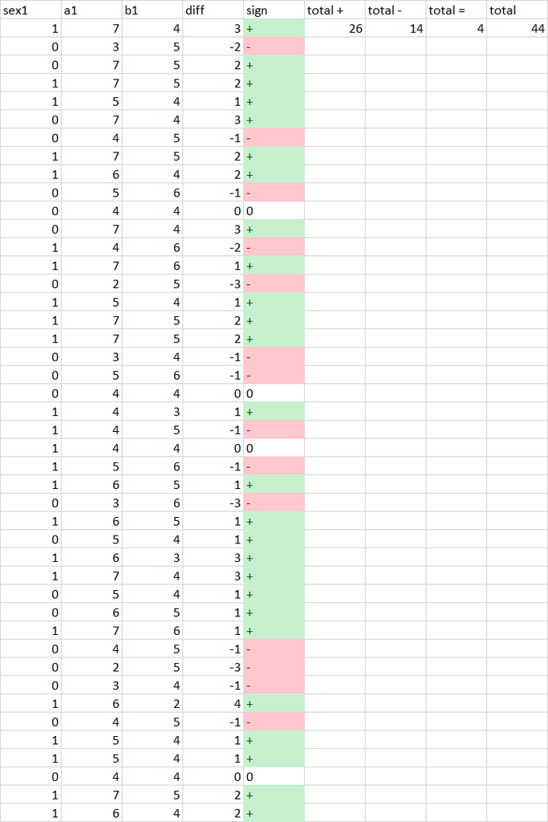

Попробуем проверить гипотезу о том, что потенциальный потребитель предпочитает воду A воде B на уровне значимости 10%. В 26 случаях предпочтение отдано производителю А («+»), в 14 — производителю В («-»). Обозначим за X оценку варианта А, а за Y — В.

► Сформулируем гипотезы:

$H_0 : P(X_i > Y_i) = P(X_i < Y_i)$

$H_A : P(X_i > Y_i) > P(X_i < Y_i)$

Пусть пары таковы, что $(X_1,Y_1),... ,(X_{40},Y_{40})$

$di = X_i − Yi ∼ i.i.d.$

$n^+$ ~$ Bi(40, 0.5)$ - число наблюдений, где $d_i>0 (X_i>Y_i)$

$n^−$ ~ $Bi(40, 0.5)$ число наблюдений, где $d_i<0 (X_i<Y_i)$

Выкенем наблюдения где $P(X_i = Y_i) = 0$

► Возьмём в качестве статистики $T = n^-$

► Критическая область: $T<=T_{n,\alpha}$

В пользу будут говорить значения , близкие к 0. Выберем критическую область возле 0 так, чтобы вероятность попасть туда при $H_0$ не превосходила уровень значимости 10%.

$n = n^++ n^− = 40 $

$E(n^+) = n/2$

$D(n+) = n/4 $

► n - достаточно большое

По интегральной теореме Муавра-Лапласа:

$Z =\frac{2n^- − n}{\sqrt{n}}$ ~ $N(0, 1)$

$z_\alpha= z_{0.1} = -1.23$

►$ Z<z_\alpha$ $\longrightarrow $ Попали в критическую область $\longrightarrow $ отвергаем основную в пользу альтернативной, что значит, что потенциальный потребитель предпочитает воду A воде B на уровне значимости 10%.

**2) Связано ли отношение к воде A с полом потребителя? От этого зависит стратегия продвижения товара**

$\underline{Решение}$

Воспользуемся критерием 'Ранговых сумм' ('критерий Манна — Уитни')

► Составим единый ранжированный ряд из обеих сопоставляемых выборок, расставив их элементы по степени нарастания признака и приписав меньшему значению меньший ранг (при наличии повторяющихся элементов в выборке используем средний ранг)

Общее количество рангов получится равным $N=n_{1}+n_{2}$

где $n_{1}$ — количество элементов в первой выборке,

а $n_{2}$ — количество элементов во второй выборке.

Единый ранжированный ряд:

(все данные записаны в порядке возрастания так как переносились вручную, НО потом проверялись)

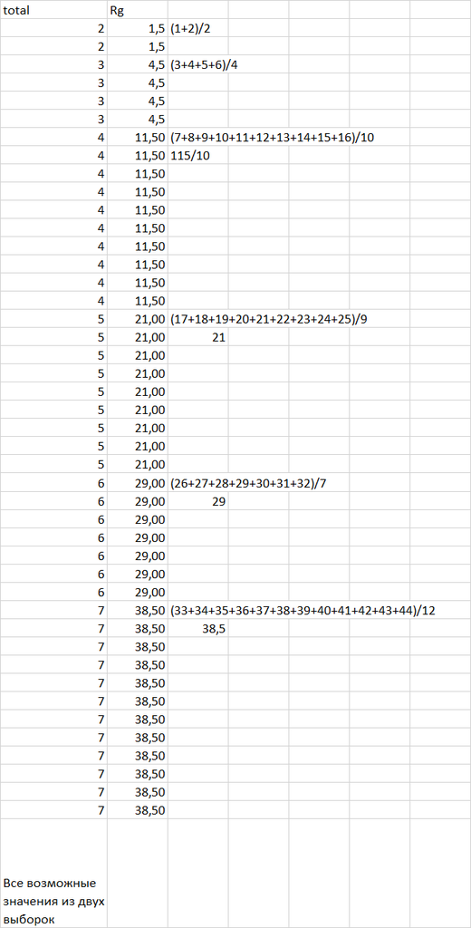

► Таблица рангов для каждой из выборок:

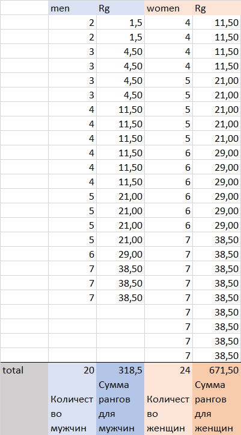

► Сформулируем гипотезы:

$H_0 : $ Пол не влияет на ответы респондентов

$H_A : $ Пол влияет на ответы респондентов

► Сумма рангов для мужчин: $R_m=\sum^{20}_{i=1}Rg_i=318.5$

► Сумма рангов для женщин: $R_w=\sum^{24}_{i=1}Rg_i=671.5$

► БОльшая ранговая сумма: $R_w=671.5$

► Вычислим значение статистики $U = n1·n2 + n_x·(n_x + 1)/2 – T_x,$

где $n_1$ – объем выборки №1;

$n_2$ – объем выборки №2;

$T_x$ – большая из двух ранговых сумм;

$n_x$ – объем максимальной выборки: $n_x= max(n1, n2).$

В нашем случае: $U = 20·24 + 24·(24 + 1)/2 – 671.5=108.5$

►Критическое правило: $U_{эмп} ≤ U_{кр}$ -- H0 отвергается.

Определим критические значения $U_{кр}$ по таблице. Так как гипотеза двусторонняя, то ищем $U_{0.05}=169$

$U_{эмп}<U(0.05)$

$\longleftrightarrow$

$108.5<169$

► Наше значение попадает в зону значимости (в критическую зону), что говорит о том, что пол влияет на выставление оценки воде производителя А. Следовательно и стратегию продвижения товара надо выробатывать согласно тому, что пол влияет